# Project 1: Wrangling, Exploration, Visualization

SDS322E

## Data Wrangling, Exploration, Visualization

### Kaelen Saythongkham

#### Introduction

Howdy! For this project, I decided to pick two datasets that I thought would create an interesting project. I chose one dataset (AKC_Breed_Info) that has the sizes of all dog breeds. It has the lower end of their height and weight as well as the upper end of their height and weight. I thought this was interesting because you could calculate both the range and average/mean height and weight for each breed.

The next dataset I chose was dog_intelligence. I thought this dataset was particularly interesting because it contains a classification of the dog, which describes the breed type, as well as the probability it obeys on the first command, and the lower/upper limits of repetitions needed for that breed to understand a new command.

I was super interested in these sets together because the data allows for a multitude of different directions to go about determining if based on breed, does dog size affects their intelligence?

```r
library(tidyverse)

# reading all my datasets in
data1 <- read_csv("./AKC_Breed_Info.csv")
data2 <- read_csv("./dog_intelligence.csv")
data3 <- read_csv("./fci-breeds.csv")
```

#### Tidying: Reshaping

```r
# untidy and retidy dataset1
data1 %>%
    pivot_wider(contains("height_low")) %>%
    pivot_longer(contains("height_low"))
```

```
## # A tibble: 29 × 2
##    name              value
##    <chr>             <chr>
##  1 height_low_inches 26
##  2 height_low_inches 27
##  3 height_low_inches 23
##  4 height_low_inches 24
##  5 height_low_inches 25
##  6 height_low_inches 32
##  7 height_low_inches 28
##  8 height_low_inches 22
##  9 height_low_inches na
## 10 height_low_inches 21
## # … with 19 more rows
```

#### Joining/Merging

```r
# number of rows and distinct rows in data1
nrow(data1)
```

```
## [1] 150
```

```r
nrow(distinct(data1))
```

```
## [1] 150
```

```r
# number of rows and distinct rows in data2
nrow(data2)
```

```
## [1] 136
```

```r
nrow(distinct(data2))
```

```
## [1] 136
```

```r
# number of rows and distinct rows in data3
nrow(data3)
```

```
## [1] 354
```

```r
nrow(distinct(data3))
```

```
## [1] 354
```

```r
# full join data1 and data2
joined_data <- data1 %>%
    full_join(data2, by = "Breed")

# mutate dataset3 and join it with joined_data
data3 <- data3 %>%
    mutate(Breed = str_to_title(name)) %>%
    select(Breed, section, country)
full_data <- joined_data %>%
    full_join(data3, by = "Breed")

# number of rows and distinct rows in the joined datasets
nrow(full_data)
```

```
## [1] 422
```

```r
nrow(distinct(full_data))
```

```
## [1] 422
```

```r
# getting all rows that one dataset has that the other does
# not
data1 %>%
    anti_join(data2, by = "Breed") %>%
    nrow()
```

```
## [1] 45
```

```r
data1 %>%
    anti_join(data3, by = "Breed") %>%
    nrow()
```

```
## [1] 56
```

```r
data2 %>%
    anti_join(data1, by = "Breed") %>%
    nrow()
```

```
## [1] 31
```

```r
data2 %>%
    anti_join(data3, by = "Breed") %>%
    nrow()
```

```
## [1] 37
```

```r
data3 %>%
    anti_join(data1, by = "Breed") %>%
    nrow()
```

```
## [1] 260
```

```r
data3 %>%
    anti_join(data2, by = "Breed") %>%
    nrow()
```

```
## [1] 255
```

#### Wrangling

```r
# converting all 'n/a' values to NA and removing all NA
full_data %>%
    na_if("n/a") %>%
    na.omit() -> full_data

# updating the data to include avg_height and avg_weight
full_data_updated <- full_data %>%
    select(Breed, height_low_inches, height_high_inches, weight_low_lbs,
        weight_high_lbs, Classification, obey, country, section) %>%
    group_by(Breed) %>%
    mutate(avg_height = ((as.integer(height_high_inches) + as.integer(height_low_inches))/2),
        avg_weight = ((as.integer(weight_low_lbs) + as.integer(weight_high_lbs))/2)) %>%
    arrange(desc(obey))

# create new columns for small and large dogs
full_data_updated %>%
    mutate(size = ifelse(avg_height >= 18, "large", "small"),
        obey = toString(obey)) -> full_data_updated

# remove percentage sign on obey variable and make an int
full_data_updated %>%
    mutate(obey = str_replace_all(obey, "%", "")) %>%
    mutate(obey = as.integer(obey)) -> full_data_updated

# group by classification and calculate summary stats
full_data_updated %>%
    na.omit() %>%
    group_by(Classification) %>%
    summarize(mean_height = mean(avg_height), mean_weight = mean(avg_weight),
        height_sd = sd(avg_height), count = n(), max_weight = max(avg_weight),
        min_height = min(avg_height), mean_obey = mean(obey)) %>%
    knitr::kable()
```

| Classification | mean_height | mean_weight | height_sd | count | max_weight | min_height | mean_obey |
| --- | --- | --- | --- | --- | --- | --- | --- |
| Above Average Working Dogs | 19.09091 | 46.77273 | 5.733436 | 22 | 125.0 | 8.0 | 70 |
| Average Working/Obedience Intelligence | 20.52000 | 51.68000 | 6.654384 | 25 | 140.0 | 10.0 | 50 |
| Brightest Dogs | 21.60000 | 62.50000 | 2.355844 | 5 | 100.0 | 18.5 | 95 |
| Excellent Working Dogs | 19.80000 | 59.00000 | 6.027023 | 5 | 97.5 | 11.5 | 85 |
| Fair Working/Obedience Intelligence | 13.73077 | 26.61538 | 5.670153 | 13 | 115.0 | 7.5 | 30 |

```r
calc_se <- function(sd, count) {
    se <- sd/count
    return(se)
}

# group by classification and size and calculate summary
# stats
full_data_updated %>%
    na.omit() %>%
    group_by(size, Classification) %>%
    summarize(mean_obey = mean(obey), sd = sd(avg_height), count = n(),
        avg_height = avg_height, se = calc_se(sd, count), Breed = Breed) ->
    full_data_stats
full_data_stats
```

```
## # A tibble: 70 × 8
## # Groups:   size, Classification [9]
##    size  Classification             mean_obey    sd count avg_height    se Breed
##    <chr> <chr>                          <dbl> <dbl> <int>      <dbl> <dbl> <chr>
##  1 large Above Average Working Dogs        70  2.97    15       27   0.198 Newf…
##  2 large Above Average Working Dogs        70  2.97    15       25   0.198 Bria…
##  3 large Above Average Working Dogs        70  2.97    15       23.5 0.198 Ches…
##  4 large Above Average Working Dogs        70  2.97    15       19.5 0.198 Clum…
##  5 large Above Average Working Dogs        70  2.97    15       25   0.198 Engl…
##  6 large Above Average Working Dogs        70  2.97    15       26.5 0.198 Gian…
##  7 large Above Average Working Dogs        70  2.97    15       25   0.198 Gord…
##  8 large Above Average Working Dogs        70  2.97    15       18   0.198 Amer…
##  9 large Above Average Working Dogs        70  2.97    15       21   0.198 Bear…
## 10 large Above Average Working Dogs        70  2.97    15       21   0.198 Dalm…
## # … with 60 more rows
```

When first starting this project, I did not realize how much formatting and tidying would be required to do any sort of summary statistics. The most interesting thing was how similar the mean_obey for each classification was for large and small dogs. When I first calculated the mean_height for the classification, I was curious how different it would be for each size, which is based on height. I assumed that the size may have changed the temperament of the breed, but it seems to be relatively similar across the board! This implies that there may not be an obvious difference between intelligence of smaller dogs compared to the intelligence of larger dogs. This is assuming we base dog intelligence on their ability to obey a command on first try.

#### Visualizing

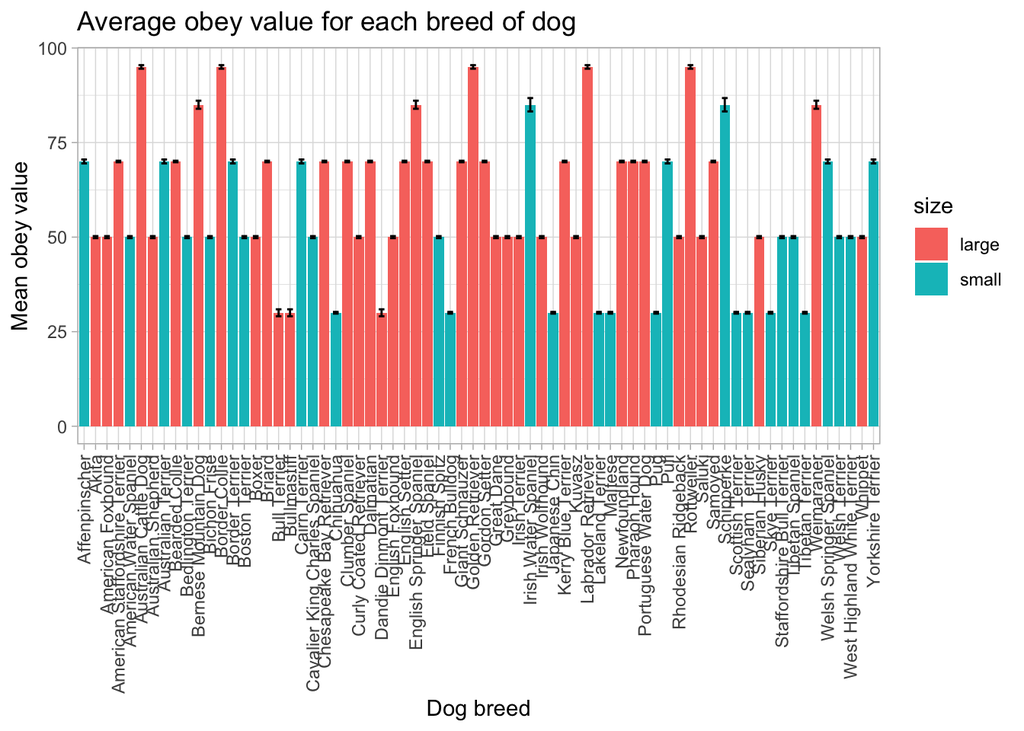

```r
ggplot(data = full_data_stats) + geom_bar(stat = "summary", aes(x = Breed,
    y = mean_obey, fill = size)) + geom_errorbar(aes(x = Breed,
    ymin = mean_obey - se, ymax = mean_obey + se), width = 0.5) +
    ggtitle("Average obey value for each breed of dog") + xlab("Dog breed") +
    ylab("Mean obey value") + theme_light() + theme(axis.text.x = element_text(angle = 90,
    vjust = 0.5, hjust = 1))
```

This graph is a little hard to read due to the number of different dog breeds, but it provides interesting data. The colouring by size highlights the differences between the mean obey values for each size. It may seem obvious that larger sizes have a larger obey value, but when looking at the distribution overall, there seems to be no difference.

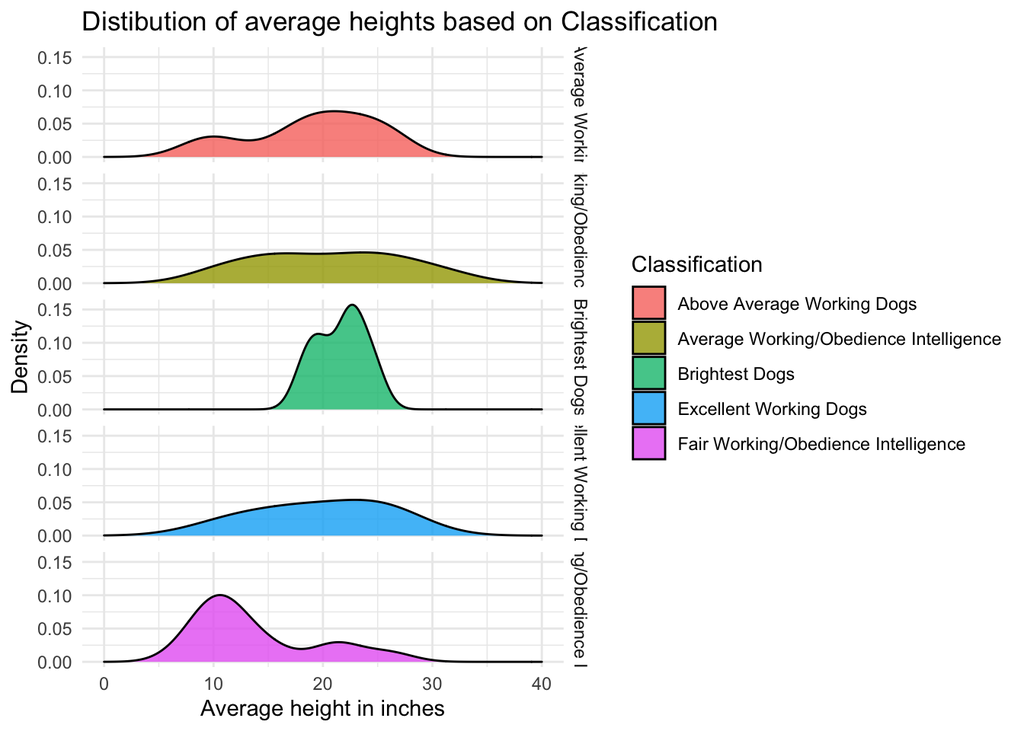

```r
ggplot(data = full_data_updated, aes(x = avg_height, fill = Classification)) +
    geom_density(alpha = 0.8) + facet_grid(rows = vars(Classification)) +
    ggtitle("Distibution of average heights based on Classification") +
    xlab("Average height in inches") + ylab("Density") + scale_x_continuous(limits = c(0,
    40)) + theme_minimal()
```

This plot shows the distribution of the average heights based on the dog’s classification. I thought this was particularly interesting because the distributions allow for a clearer picture of the average heights of each classification of dog. Some of them have a similar distribution, which then highlights the distribution of the “Brightest Dogs” and “Fair Working/Obedience Intelligence,” which I thought was nice.

[figure not shown]

```r
ggplot(data = full_data_updated, aes(x = Breed, y = avg_height,
    color = Classification)) + geom_point() + geom_line() + ggtitle("Average height for each breed of dog") +
    xlab("Dog breed") + ylab("Average height") + theme(axis.text.x = element_text(angle = 90,
    vjust = 0.5, hjust = 1), legend.title = element_text(size = 3),
    legend.text = element_text(size = 5), legend.key.size = unit(1,
        "lines"))
```

This graph looks a little messy due to the amount of dog breeds, but the colouring by classification shows that there is no obvious distinction between dog breeds, classification, and the average heights. I really liked this plot because it obviously shows that there is no distinction, while the other plots implied.

#### Concluding Remarks

This project was much harder than I anticipated. I went back and forth between datasets because I was not sure if they would cover what was needed or if there was sufficient data to complete the summary statistics. Overall, I concluded that there is not a sufficient difference between small and large dogs regarding intelligence. Larger dogs seem to have a greater average, but it is not sufficient enough to claim size influences intelligence.